# Part I - (Dataset Exploration Title)

## Dealing with missing values

1. For all numeric attributes with missing values (**ProsperScore,EmploymentStatusDuration,DebtToIncomeRatio,StatedMonthlyIncome, StatedMonthlyIncome,MonthlyLoanPayment**) I am going to replace them with their mean.
2. For the categorical attributes, i will drop all rows with missing values

```python
df2.ProsperScore.describe()
```

```
count    84853.000000
mean         5.950067
std          2.376501
min          1.000000
25%          4.000000
50%          6.000000
75%          8.000000
max         11.000000
Name: ProsperScore, dtype: float64
```

```python
# Replace the NaNs in columns (ProsperScore,EmploymentStatusDuration,DebtToIncomeRatio,StatedMonthlyIncome, StatedMonthlyIncome,MonthlyLoanPayment) by the mean of values

df2[['ProsperScore','EmploymentStatusDuration','DebtToIncomeRatio', 'StatedMonthlyIncome','MonthlyLoanPayment']] = df2[['ProsperScore','EmploymentStatusDuration','DebtToIncomeRatio', 'StatedMonthlyIncome','MonthlyLoanPayment']].fillna(df2[['ProsperScore','EmploymentStatusDuration','DebtToIncomeRatio', 'StatedMonthlyIncome','MonthlyLoanPayment']].mean())
```

```python
#checking if the missing values are replaced
df2.info()
```

```
<class 'pandas.core.frame.DataFrame'>
RangeIndex: 113937 entries, 0 to 113936
Data columns (total 15 columns):
 #   Column                    Non-Null Count   Dtype
---  ------                    --------------   -----
 0   Term                      113937 non-null  int64
 1   LoanStatus                113937 non-null  object
 2   BorrowerRate              113937 non-null  float64
 3   ProsperScore              113937 non-null  float64
 4   ListingCategory           113937 non-null  object
 5   BorrowerState             108422 non-null  object
 6   Occupation                110349 non-null  object
 7   EmploymentStatusDuration  113937 non-null  float64
 8   EmploymentStatus          111682 non-null  object
 9   IsBorrowerHomeowner       113937 non-null  bool
 10  DebtToIncomeRatio         113937 non-null  float64
 11  IncomeRange               113937 non-null  object
 12  StatedMonthlyIncome       113937 non-null  float64
 13  LoanOriginalAmount        113937 non-null  int64
 14  MonthlyLoanPayment        113937 non-null  float64
dtypes: bool(1), float64(6), int64(2), object(6)
memory usage: 12.3+ MB
```

```python
#dropping nan valua for all columns with categorical values
df2.dropna(inplace=True)
```

```python
df2.info()
```

```
<class 'pandas.core.frame.DataFrame'>
Int64Index: 106221 entries, 0 to 113936
Data columns (total 15 columns):
 #   Column                    Non-Null Count   Dtype
---  ------                    --------------   -----
 0   Term                      106221 non-null  int64
 1   LoanStatus                106221 non-null  object
 2   BorrowerRate              106221 non-null  float64
 3   ProsperScore              106221 non-null  float64
 4   ListingCategory           106221 non-null  object
 5   BorrowerState             106221 non-null  object
 6   Occupation                106221 non-null  object
 7   EmploymentStatusDuration  106221 non-null  float64
 8   EmploymentStatus          106221 non-null  object
 9   IsBorrowerHomeowner       106221 non-null  bool
 10  DebtToIncomeRatio         106221 non-null  float64
 11  IncomeRange               106221 non-null  object
 12  StatedMonthlyIncome       106221 non-null  float64
 13  LoanOriginalAmount        106221 non-null  int64
 14  MonthlyLoanPayment        106221 non-null  float64
dtypes: bool(1), float64(6), int64(2), object(6)
memory usage: 12.3+ MB
```

```python
df2.ProsperScore.value_counts()
```

```
5.950067     22701
4.000000     12257
6.000000     12126
8.000000     11942
7.000000     10448
5.000000      9683
3.000000      7436
9.000000      6875
2.000000      5619
10.000000     4712
11.000000     1436
1.000000       986
Name: ProsperScore, dtype: int64
```

> After cleaning the final data set has 106,221 records and 15 columns

## Univariate Exploration

> In this section, investigate distributions of individual variables. If you see unusual points or outliers, take a deeper look to clean things up and prepare yourself to look at relationships between variables.

> **Rubric Tip**: The project (Parts I alone) should have at least 15 visualizations distributed over univariate, bivariate, and multivariate plots to explore many relationships in the data set. Use reasoning to justify the flow of the exploration.

> **Rubric Tip**: Use the "Question-Visualization-Observations" framework throughout the exploration. This framework involves **asking a question from the data, creating a visualization to find answers, and then recording observations after each visualisation.**

### Question 1: What is the distribution of the debt to income ratio in the dataset?

the debit to income ratio is the ratio of borrowers debt and their monthly income. if the ratio is lower it means that the borrowers have less debt than their income. if the ratio is higher. i.e greater than 1 it would mean that the borrower has more debt than their monthly earning

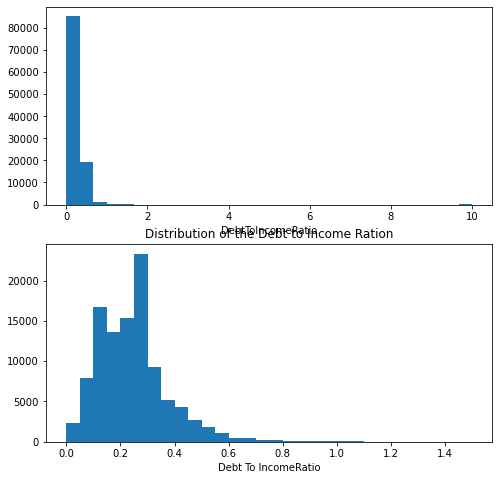

```python
# A plot of DebtToIncomeRatio.

plt.figure(figsize=(8, 8))

plt.subplot(2,1,1)
#in this subplot i will plot a histogram of bins set at 30.
plt.hist(data=df2, x='DebtToIncomeRatio', bins=30)
plt.xlabel('DebtToIncomeRatio');

plt.subplot(2,1,2)
#in the first subplot i have observed that the distribution  is between 0 and 2.
#in the second subplot I will plot the histogram between the x values 0 and 2 to show more details
binsize = 0.05
bins = np.arange(0, 1.5 + binsize, binsize)
plt.hist(data=df2, x='DebtToIncomeRatio', bins=bins)
plt.xlabel('Debt To IncomeRatio');
plt.title('Distribution of the Debt to Income Ration');
```

### Observation

The distribution is skewed to the right.from the graphs the debt to income ratio largely, is between 0 and 0.5. This means that for a majority of borrowers their "debt to income ratio" in low. This implies that most borrowers have less debt than their monthly income. However there are a few borrower whose "debt to income ratio" is above 1 and this is not a good sign

### Question 2: what is the distribution of the income range of the borrowers

```python
#ordering the income ranges in column "IncomeRange" for easier intepretation
income_ordered = ["Not employed","Not displayed","$0","$1-24,999","$25,000-49,999","$50,000-74,999","$75,000-99,999","$100,000+"]
df2['IncomeRangeOrdered'] = pd.Categorical(df2['IncomeRange'], categories=income_ordered, ordered=True)
df2.head()
```

|  | Term | LoanStatus | BorrowerRate | ProsperScore | ListingCategory | BorrowerState | Occupation | EmploymentStatusDuration | EmploymentStatus | IsBorrowerHomeowner | DebtToIncomeRatio | IncomeRange | StatedMonthlyIncome | LoanOriginalAmount | MonthlyLoanPayment | IncomeRangeOrdered |
| --- | --- | --- | --- | --- | --- | --- | --- | --- | --- | --- | --- | --- | --- | --- | --- | --- |
| 0 | 36 | Completed | 0.1580 | 5.950067 | Not Available | CO | Other | 2.000000 | Self-employed | True | 0.17 | $25,000-49,999 | 3083.333333 | 9425 | 330.43 | $25,000-49,999 |
| 1 | 36 | Current | 0.0920 | 7.000000 | Home Improvement | CO | Professional | 44.000000 | Employed | False | 0.18 | $50,000-74,999 | 6125.000000 | 10000 | 318.93 | $50,000-74,999 |
| 2 | 36 | Completed | 0.2750 | 5.950067 | Not Available | GA | Other | 96.071582 | Not available | False | 0.06 | Not displayed | 2083.333333 | 3001 | 123.32 | Not displayed |
| 3 | 36 | Current | 0.0974 | 9.000000 | Motorcycle | GA | Skilled Labor | 113.000000 | Employed | True | 0.15 | $25,000-49,999 | 2875.000000 | 10000 | 321.45 | $25,000-49,999 |
| 4 | 36 | Current | 0.2085 | 4.000000 | Home Improvement | MN | Executive | 44.000000 | Employed | True | 0.26 | $100,000+ | 9583.333333 | 15000 | 563.97 | $100,000+ |

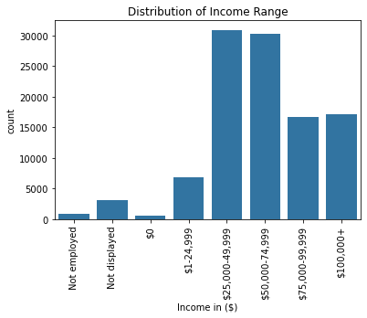

```python
# plotting a barchart of borrowers income range.
# Income range is a categorical ordinal variable and should be ordered to give the correct message

type_order = df2['IncomeRange'].value_counts().index
default_color = sb.color_palette()[0]
sb.countplot(data = df2, x = 'IncomeRangeOrdered', color = default_color);
plt.xticks(rotation=90);
plt.title("Distribution of Income Range");
plt.xlabel('Income in ($)');
```

### Observation

borrowers that make within 25,000-49,999 and 50,000-74,999 are most prevalent in this dataset, meaning that they are more likely to get or apply for a loan.those that earn above 75,000 are less likely to apply for a loan than the first and second groups. this could be because they earn enough. those that are not employed or do not make any income are less likely to apply for a loan.

### Question 3: what are the common reasons why people take loans?

```python
#ordering the income ranges in column "IncomeRange" for easier intepretation
income_ordered = ["Not employed","Not displayed","$0","$1-24,999","$25,000-49,999","$50,000-74,999","$75,000-99,999","$100,000+"]
df2['IncomeRangeOrdered'] = pd.Categorical(df2['IncomeRange'], categories=income_ordered, ordered=True)
df2.head()
```

[output not shown]

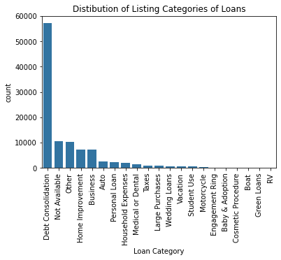

```python
# plotting a barchart of borrowers Listing Category.
# Listing Category is a categorical ordinal variable and shoyld be ordered to give the correct message

type_order = df2['ListingCategory'].value_counts().index
default_color = sb.color_palette()[0]
sb.countplot(data = df2, x = 'ListingCategory', color = default_color, order = type_order);
plt.xticks(rotation=90);
plt.title('Distibution of Listing Categories of Loans');
plt.xlabel('Loan Category');
```

### Observation

The most common reasons for taking loans is debt consolidation. According to wikepedia,debt consolidation is a form of debt refinancing that entails taking out one loan to pay off many others. This loan may be common because it offers borrowers a chance to settle their other loans from one place/loan hence making loan payment more manageable.

### Question 4: What is the distribution of the monthly loan payments in the dataset?

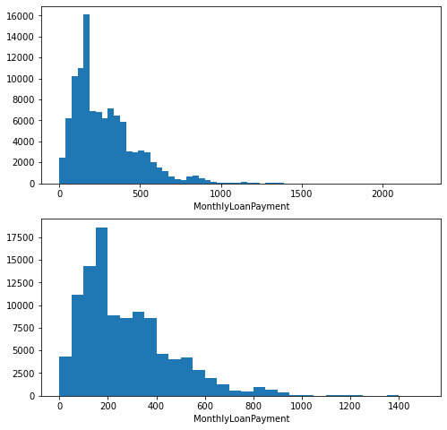

```python
#df2.MonthlyLoanPayment.value_counts()
plt.figure(figsize=(8, 8))

# plot of DebtToIncomeRatio.

plt.figure(figsize=(8, 8))

plt.subplot(2,1,1)
#in this subplot i will plot a histogram of bins set at 60.
plt.hist(data=df2, x='MonthlyLoanPayment', bins=60)
plt.xlabel('MonthlyLoanPayment');

plt.subplot(2,1,2)
#in the first subplot i have observed that the distribution  is between 0 and 1400.
#in the second subplot I will plot the histogram between the x values 0 and 1400 to show more details
binsize = 50
bins = np.arange(0, 1500 + binsize, binsize)
plt.hist(data=df2, x='MonthlyLoanPayment', bins=bins)
plt.xlabel('MonthlyLoanPayment');
```

```python
df2.MonthlyLoanPayment.mean()
```

```
277.9274696152587
```

### Obseravtion

The distribution is skewed to the right. Here we observe that the peak is at around 180 dollars for the monthly payments

### Question five: what is the distribution of the house owner and employemnt status ?

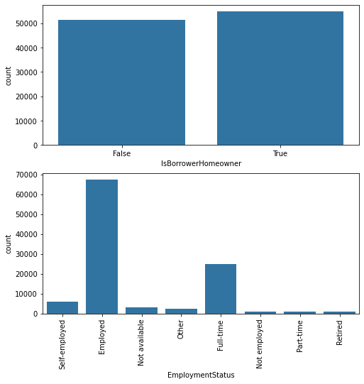

```python
# Plotting all the two cgarts together to get an idea of each ordinal variable's distribution.

fig, ax = plt.subplots(nrows=2, figsize = [8,8])

default_color = sb.color_palette()[0]

sb.countplot(data = df2, x = 'EmploymentStatus', color = default_color, ax = ax[1])

sb.countplot(data = df2, x = 'IsBorrowerHomeowner', color = default_color, ax = ax[0])

plt.xticks(rotation=90);
plt.show()
```

### Observation

1. There isnt much difference between the home owners and non home owners in loan access. This might imply that having a home may not be a necessity in getting a loan, howver further analysis on this will be done under bivariate and multivariate analysis.
2. The employeed borrowers take up the most. This is expected as lending institutions want to find employeed borrowers who will be able to make their monthly payments

### Discuss the distribution(s) of your variable(s) of interest. Were there any unusual points? Did you need to perform any transformations?

> The distributions were quite ok. there was no need to do transormation on the features that i have chose even such need may arise for other features

### Of the features you investigated, were there any unusual distributions? Did you perform any operations on the data to tidy, adjust, or change the form of the data? If so, why did you do this?

> all operations to tidy up the data were done at the cleaning stage

## Bivariate Exploration

> In this section, investigate relationships between pairs of variables in your data. Make sure the variables that you cover here have been introduced in some fashion in the previous section (univariate exploration).

The bivariate analysis will be done in three types:

1. numerical to numerical analysis
2. categorical to categorical analysis
3. numerical to categorical analysis

```python
#a Plot of loan amount vs house owner status
df2.IncomeRange.value_counts()
```

```
$25,000-49,999    30919
$50,000-74,999    30304
$100,000+         17136
$75,000-99,999    16640
$1-24,999          6778
Not displayed      3060
Not employed        781
$0                  603
Name: IncomeRange, dtype: int64
```

### Bivariate analysis of numerical variables

It is important that we first establish that there is indeed correlation between our variables of choice. Therefore before performing the bivariate analysis i will find the pairwise correlation of all my numerical or continous variable.

```python
#To find the correlation among the columns using pearson method

df2.corr(method ='pearson')
```

|  | Term | BorrowerRate | ProsperScore | EmploymentStatusDuration | IsBorrowerHomeowner | DebtToIncomeRatio | StatedMonthlyIncome | LoanOriginalAmount | MonthlyLoanPayment |
| --- | --- | --- | --- | --- | --- | --- | --- | --- | --- |
| Term | 1.000000 | 0.016579 | 0.027462 | 0.080820 | 0.077713 | -0.014081 | 0.025791 | 0.337463 | 0.082685 |
| BorrowerRate | 0.016579 | 1.000000 | -0.572735 | -0.021912 | -0.134744 | 0.065452 | -0.087962 | -0.344385 | -0.259798 |
| ProsperScore | 0.027462 | -0.572735 | 1.000000 | -0.008385 | 0.054523 | -0.078064 | 0.078696 | 0.235287 | 0.149179 |
| EmploymentStatusDuration | 0.080820 | -0.021912 | -0.008385 | 1.000000 | 0.169353 | -0.007060 | 0.068148 | 0.096155 | 0.079289 |
| IsBorrowerHomeowner | 0.077713 | -0.134744 | 0.054523 | 0.169353 | 1.000000 | -0.001917 | 0.136726 | 0.197836 | 0.170420 |
| DebtToIncomeRatio | -0.014081 | 0.065452 | -0.078064 | -0.007060 | -0.001917 | 1.000000 | -0.077364 | 0.004084 | 0.021710 |
| StatedMonthlyIncome | 0.025791 | -0.087962 | 0.078696 | 0.068148 | 0.136726 | -0.077364 | 1.000000 | 0.197717 | 0.193866 |
| LoanOriginalAmount | 0.337463 | -0.344385 | 0.235287 | 0.096155 | 0.197836 | 0.004084 | 0.197717 | 1.000000 | 0.929219 |
| MonthlyLoanPayment | 0.082685 | -0.259798 | 0.149179 | 0.079289 | 0.170420 | 0.021710 | 0.193866 | 0.929219 | 1.000000 |

From the above correlation table i will consider the below correations for my numerical to numerical Bivariate analysis

1. term and loan amount
2. prosper score and borrower rate
3. loan payment and stated monthly income

### Question 6: How is term and loan amount related?

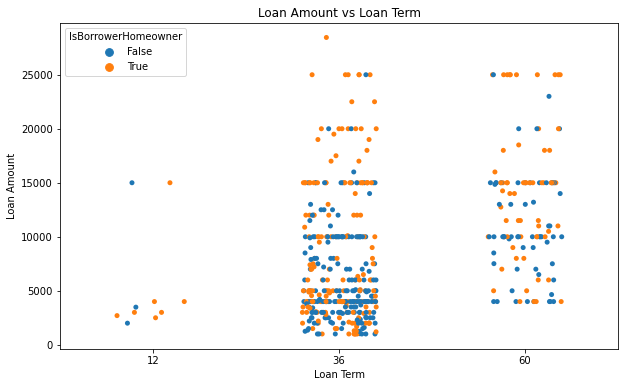

```python
plt.figure(figsize = [10, 6])

sb.stripplot(data = df2.sample(500, random_state=1), x = 'Term', y = 'LoanOriginalAmount', hue='IsBorrowerHomeowner', jitter=0.2);
plt.xlabel('Loan Term');
plt.ylabel('Loan Amount');
plt.title('Loan Amount vs Loan Term');
```

### Observation

it is expected that the bigger the loan the longer the term for payment.in the grapher the dark colored parts shows the concetration of points for a particular term. Adding the hue for home ownership shows that borrowers taking a bigger loans. over longer terms and are home owners are preffered.

### Question 7: How is prosper score and borrower rate related?

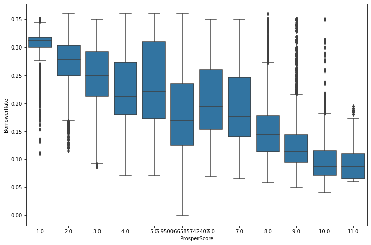

```python
plt.figure(figsize = [12, 8])
sb.boxplot(data = df2, x = 'ProsperScore', y = 'BorrowerRate', color = default_color);
```

### Observation

the lower the prosper score the higher the interest. This means that at prosper borrowers with a lower loan score are given high interest. This could be because the lender will want to make less losses if the loan goes bad.

### Question 8: how is loan payment and stated monthly income related?

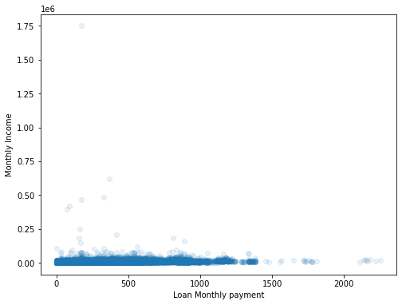

```python
plt.figure(figsize = [8, 6])
plt.scatter(data = df2, x = 'MonthlyLoanPayment', y = 'StatedMonthlyIncome', alpha = 1/10);
plt.xlabel('Loan Monthly payment');
plt.ylabel('Monthly Income');
```

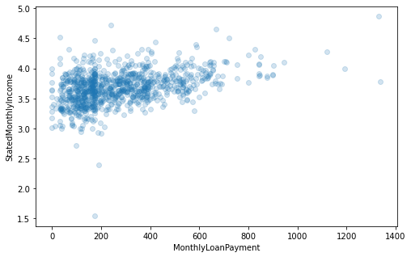

```python
#to avoid overplotting, i will limit the number of records to 2000 with the selection of the records being done randomly
# the monthly income is also log transformed for a clealer vizualization
plt.figure(figsize=(8, 5))
df2['StatedMonthlyIncome_log10'] = np.log10(df2['StatedMonthlyIncome'])
plt.scatter(data= df2.sample(1000, random_state=1), x='MonthlyLoanPayment', y='StatedMonthlyIncome_log10', alpha=0.2)
plt.xlabel('MonthlyLoanPayment')
plt.ylabel('StatedMonthlyIncome');
```

### Observation

there is a linear relationship between the monthly income and monthly payment in that as the monthly income increases the monthtly loan payment slightly increases also.it is suprising that according to the plot a majority of high income earners still opt for loans with small monthly payments, this mightimply that a majority of the population make smart fiancial decisions

### Bivariate analysis of categorical variables

loan status and income range, home owner

### Question 9: How us loan status and loan score related amongst borrowers with or without a house??

```python
df2.IncomeRange.value_counts()
```

```
$25,000-49,999    30919
$50,000-74,999    30304
$100,000+         17136
$75,000-99,999    16640
$1-24,999          6778
Not displayed      3060
Not employed        781
$0                  603
Name: IncomeRange, dtype: int64
```

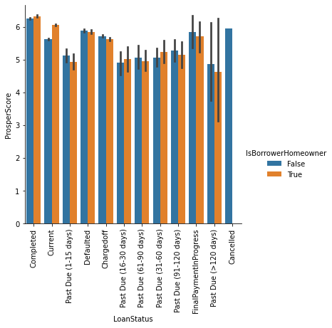

```python
sb.catplot(data=df2, x="LoanStatus", y="ProsperScore", hue="IsBorrowerHomeowner", kind="bar")
#sb.barplot(data=df2, x="IncomeRange", y="ProsperScore", hue="IsBorrowerHomeowner", kind="bar",ax = ax[0])
plt.xticks(rotation=90);
```

### Observation

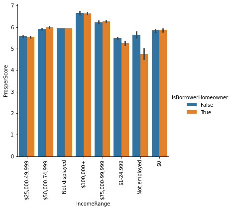

```python
sb.catplot(data=df2, x="IncomeRange", y="ProsperScore", hue="IsBorrowerHomeowner", kind="bar")
plt.xticks(rotation=90);
```

## Bivariate analysis of categorical and numerical variables

1. loan amount and listing category, employment status, homeownership
2. borower state, term, income range and borrower interest

```python
#here i will make a plot of loan amoount against listing category, employment status, homeownership
#selecting my columns of interest into special cols variable
special_cols =['ListingCategory','EmploymentStatus', 'IsBorrowerHomeowner']
```

```python
#Getting the index of my variables of interest
list(enumerate(special_cols))
```

```
[(0, 'ListingCategory'), (1, 'EmploymentStatus'), (2, 'IsBorrowerHomeowner')]
```

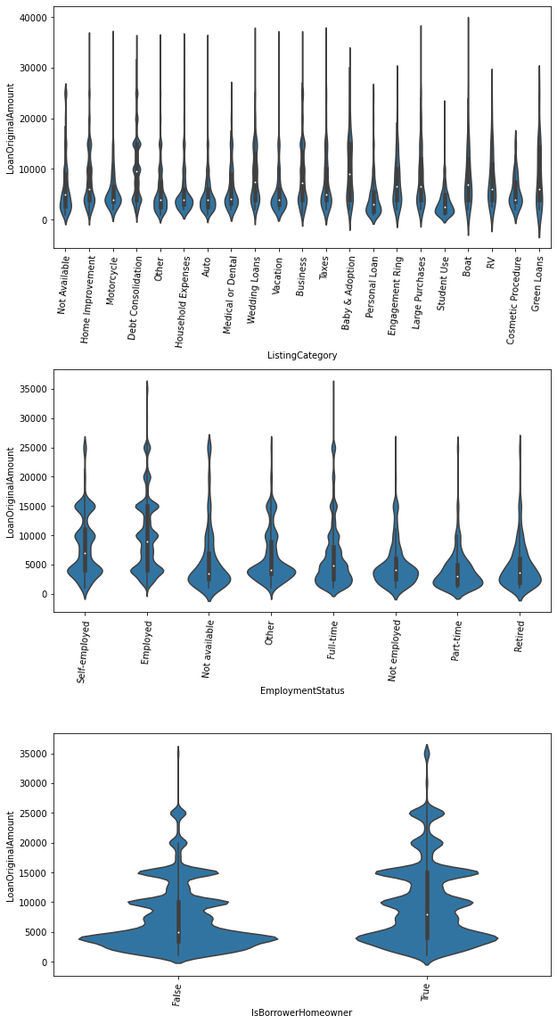

```python
# the actual plot
plt.figure(figsize = (10,20))

for i in enumerate(special_cols):
    plt.subplot(3,1,i[0]+1)
    plt.subplots_adjust(hspace=0.5)
    sb.violinplot(data = df2, x = i[1], y =  'LoanOriginalAmount', color = default_color);
    plt.xticks(rotation=85)
```

### Observations

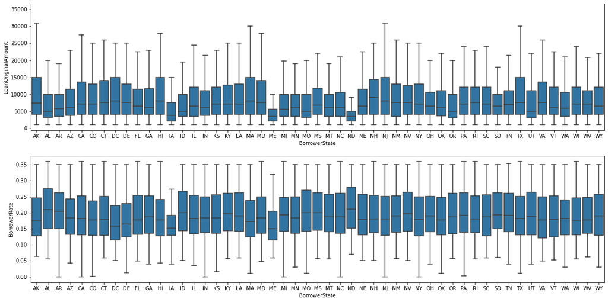

```python
#borower state, term, loan amount and borrower interest

# Create boxplot visual
plt.figure(figsize=(20, 10))
plt.subplot(2,1,1)
sb.boxplot(data=df2.sort_values(by='BorrowerState'), x='BorrowerState', y='LoanOriginalAmount',
            fliersize=0, color=default_color);
plt.subplot(2,1,2)
sb.boxplot(data=df2.sort_values(by='BorrowerState'), x='BorrowerState', y='BorrowerRate',
            fliersize=0, color=default_color);
```

### Observation

1. From the subplot 1, NH is the state with the highest loan amount, while IA,ME and ND have the lowest loan ampunt per state
2. From the 2nd subplot AL has the highest interest rate per state whileIA has the lowest interest rate per state.  
   However there is no clear relationship between loan amount and interest rate per state. We might need extra information to investigate the trends further

### Talk about some of the relationships you observed in this part of the investigation. How did the feature(s) of interest vary with other features in the dataset?

> Key take aways from the bivariate analysis include:
> 1. There is a linear relationship between monthly income and monthly payment
> 2. There is also an inverse relationship between interest rate and loan score. The lower the interest rate the higher the loan score.

### Did you observe any interesting relationships between the other features (not the main feature(s) of interest)?

> i noted that there is not much difference in how home owners or non home owners are rated in terms of scores

## Multivariate Exploration

> Create plots of three or more variables to investigate your data even further. Make sure that your investigations are justified, and follow from your work in the previous sections.

```python
df2.LoanStatus.value_counts()
```

```
Current                   55272
Completed                 33768
Chargedoff                10833
Defaulted                  4091
Past Due (1-15 days)        798
Past Due (31-60 days)       358
Past Due (61-90 days)       313
Past Due (91-120 days)      304
Past Due (16-30 days)       264
FinalPaymentInProgress      203
Past Due (>120 days)         16
Cancelled                     1
Name: LoanStatus, dtype: int64
```

```python
loanstatus_ordered = ["Current", "Completed", "Chargedoff","Defaulted","FinalPaymentInProgress","Cancelled", "Past Due (1-15 days)", "Past Due (16-30 days)","Past Due (31-60 days)","Past Due (61-90 days)","Past Due (91-120 days)","Past Due (>120 days)"]

df2['LoanStatusOrdered'] = pd.Categorical(df2['LoanStatus'], categories=loanstatus_ordered, ordered=True)
```

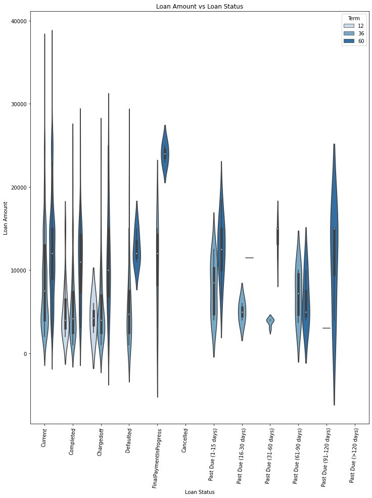

```python
# Visualize interactions with a seaborn relplot
plt.figure(figsize=(12, 15))
sb.violinplot(data=df2.sample(2000, random_state=1), y='LoanOriginalAmount', x='LoanStatusOrdered',
            hue='Term', palette='Blues', height=4, aspect=1.5);
plt.xticks(rotation=85);
plt.xlabel('Loan Status');
plt.ylabel('Loan Amount');
plt.title('Loan Amount vs Loan Status');
```

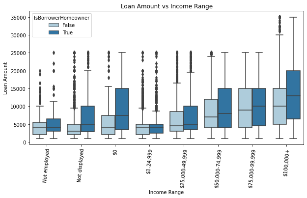

```python
plt.figure(figsize=(10, 5))
sb.boxplot(data=df2, x='IncomeRangeOrdered', y='LoanOriginalAmount', hue='IsBorrowerHomeowner', palette='Paired');
plt.xticks(rotation=85);
plt.xlabel('Income Range');
plt.ylabel('Loan Amount');
plt.title('Loan Amount vs Income Range');
```

### Talk about some of the relationships you observed in this part of the investigation. Were there features that strengthened each other in terms of looking at your feature(s) of interest?

> All along there was very subtle difference differences in how home owners and non home owners were rated in terms of loan score or the loan amounts accessed. However in the multivariate analysis it is it very clear that there is a tangible difference between home owners and non home owners especially when the income range of the two groups is factored in. Home ownerswith higher incomes have access to better/bigger loans than non home owners in the same category. Even amogst borrowers with zero source of income, those with homes are highly advanteged to get a better loan than those with no homes.

## Conclusions

This exploration of Prosper loan data was aimed at identifying the different borrower motivations when applying for loans, including the different factors that may influence loan favorability.